# Théorèmes limites et convergence de variables aléatoires

Diana Nurbakova

# Convergence de variable aléatoire

Souvent dans le monde réel, on se retrouve dans la situation où il y un certain phénomène aléatoire mais on ignore sa distribution. Il peut être impossible d’observer ce phénomène dans son intégralité directement, e.g. la taille de toutes les personnes sur Terre. Representons ce phénomène avec une variable aléatoire $X$.

Supposons qu’on peut observer certaines réalisations de ce phénomène, ou on peut prendre des mesures $X_1, X_2, ... X_n$ qui vont nous permettre d’avoir une estimation de $X$. Si on prend l’exemple de la taille des personnes, on peut mesurer la taille de certains nombre de gens dans les pays différents, par exemple.

Il paraît naturel que plus on augmente le nombre de nos mesures $n$, plus notre estimation de $X$ devient précise. Ainsi on considère que $X_n$ s’approche de $X$ avec $n\to \infty$. Autrement dit, $X_n$ *converge* vers $X$.

Quand on parle des séries numériques, on distingues les *séries divergentes* et les *séries convergentes*. Voici un exemple :

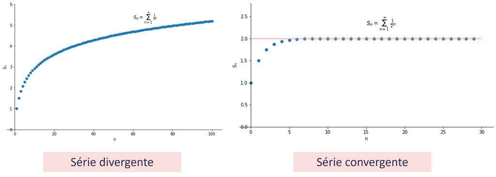

La série $S = \sum_{n=1}^{\infty}\frac{1}{n} = 1 + \frac{1}{2} + \frac{1}{3} + ... \frac{1}{k} + ... \xrightarrow[n\to \infty]{}\infty$ est divergente.

Soit $(a_1, a_2, a_3...)$ une séquence infinie des nombres. On dit que la série $S = \sum_{i=1}^{\infty}a_i$ **converge** ou est **convergente** (en. *converges* ou *convergent series*) vers $l\in \mathbb{R}$, si la suite $(S_n)_{n\in\mathbb{N}}$ de ses sommes partielles converge vers $l$ pour $\forall n\in \mathbb{N}$, i.e.

$$\forall \epsilon \in \mathbb{R}, \epsilon > 0, \ \exists N\in \mathbb{N},\ \forall n\in \mathbb{N}, n \geq N : |a_n - l| < \epsilon \Rightarrow \lim_{n\to\infty} a_n = l$$

> Mais qu’est-ce que ça veut dire la convergence de variable aléatoire ?

Par la suite, on va considérer trois type de convergence stochastique :

1. convergence en loi
2. convergence en probabilité
3. convergence presque sûre

On va se servir des définitions basées sur (Stéphane Balac and Mazet n.d.).

## Covergence en loi

Soit $(X_n)_{n\in \mathbb{N}}$ une suite de v.a.r. de fonctions de répartition respectives $(F_{X_n})_{n\in\mathbb{N}}$. Soit $X$ une v.a.r. de fonction de répartition $F_X$.

La suite $(X_n)_{n\in \mathbb{N}}$ est dite **converger en loi** (en. *convergence in distribution*) vers $X$, noté
$$X_n \xrightarrow[n\to+\infty]{\mathcal{L}}X$$

si pour $\forall x\in \mathbb{R}$ tel que $F_X$ est continue en $x$, on a :
$$\lim\limits_{n\to +\infty}F_{X_n}(x) = F_X(x)$$
**Remarque :** dans la notation anglo-saxonne :
$$X_n \xrightarrow[n\to+\infty]{d}X$$

Soit $(X_n)_{n\in \mathbb{N}}$ une suite de v.a.r. de fonctions caratéristiques respectives $(\phi_{X_n})_{n\in \mathbb{N}}$. Soit $X$ une v.a.r. Soit $\phi_X$ la fonction caractéristique de $X$.

$X_n \xrightarrow[n\to+\infty]{\mathcal{L}}X$ si et seulement si :
$$\forall t\in \mathbb{R}, \ \lim\limits_{n\to +\infty}\phi_{X_n}(t) = \phi_X(t)$$

Soit $(X_n)_{n\in \mathbb{N}}$ une suite de v.a.r. et $X$ une v.a.r. Soit $h: \mathbb{R} \to \mathbb{R}$ une fonction bornée et continue par morceaux.

$X_n \xrightarrow[n\to+\infty]{\mathcal{L}}X$ si et seulement si :
$$\lim\limits_{n\to +\infty}\mathbb{E}[h(X_n)] = \mathbb{E}[h(X)],\ \forall h$$

## Convergence en probabilité

Soit $(X_n)_{n\in \mathbb{N}}$ une suite de v.a.r.. Soit $X$ une v.a.r.. $X$ et $(X_n)_{n\in \mathbb{N}}$ sont définies sur le même espace probabilisé $(\Omega, \mathcal{A}, \mathbb{P})$.

La suite $(X_n)_{n\in \mathbb{N}}$ est dite **converger en probabilité** (en. *convergence in probability*) vers $X$, noté :
$$X_n\xrightarrow[n\to +\infty]{\mathbb{P}} X$$

si :
$$\forall \epsilon>0, \ \lim\limits_{n\to + \infty}\mathbb{P}(|X_n - X| \geq \epsilon) = 0$$

Si la suite $(X_n)_{n\in\mathbb{N}}$ converge vers $X$ en probabilité, alors elle converge vers $X$ en loi :

$$X_n\xrightarrow[n\to +\infty]{\mathbb{P}} X \Rightarrow X_n\xrightarrow[n\to +\infty]{\mathcal{L}} X$$

**Remarque :** la réciproque n’est pas vraie en général.

### Exemple

Considérons un exemple proposé par (Pishro-Nik 2014).

Soit $X$ une v.a.r. Soit $X_n = X + Y_n$, où $Y_n$ a l’espérance $\mathbb{E}Y_n = \frac{1}{n}$ et la variance $Var(Y_n) = \frac{\sigma^2}{n}$, où $\sigma > 0$ est une constante.

Montrons que $X_n \xrightarrow[n\to\infty]{\mathbb{P}}X$.

*Solution*

Pour montrer que $X_n \xrightarrow[n\to\infty]{\mathbb{P}}X$ il faut que $\lim\limits_{n\to + \infty}\mathbb{P}(|X_n - X| \geq \epsilon) = 0$.

$$\lim\limits_{n\to + \infty}\mathbb{P}(|X_n - X| \geq \epsilon) = \lim\limits_{n\to + \infty}\mathbb{P}(|(X + Y_n) - X| \geq \epsilon) = \lim\limits_{n\to + \infty}\mathbb{P}(|Y_n| \geq \epsilon)$$
Qu’est-ce qu’on peut dire par rapport à $|Y_n|$ ?

Notons que $\forall a,b \in \mathbb{R}$, l’inégalité suivante est vraie :
$$|a + b| \leq |a| + |b|$$

Posons $a = Y_n - \mathbb{E}Y_n$ et $b = \mathbb{E}Y_n$. Alors $|a + b| = |(Y_n - \mathbb{E}Y_n) + \mathbb{E}Y_n| = |Y_n|$. Donc, on obtient :
$$|Y_n| \leq |Y_n - \mathbb{E}Y_n| + |\mathbb{E}Y_n|$$

On peut remplacer $|\mathbb{E}Y_n|$ par sa valeur $\frac{1}{n}$. On obtient :
$$|Y_n| \leq |Y_n - \mathbb{E}Y_n| + \frac{1}{n}$$

Reprenons notre limite :

$$\mathbb{P}(|Y_n| \geq \epsilon) \leq \mathbb{P}\left(|Y_n - \mathbb{E}Y_n| + \frac{1}{n} \geq \epsilon\right) = \mathbb{P}\left(|Y_n - \mathbb{E}Y_n| \geq \epsilon - \frac{1}{n} \right)$$

On peut se servir de l’*inégalité de Bienaymé-Tchebychev*, selon laquelle :
$$\mathbb{P}(|X - \mathbb{E}X| \geq \alpha) \leq \frac{Var(X)}{\alpha^2}$$
Dans notre cas, $\alpha = \epsilon - \frac{1}{n}$. Donc :

$$\mathbb{P}\left(|Y_n - \mathbb{E}Y_n| \geq \epsilon - \frac{1}{n} \right) \leq \frac{Var(Y_n)}{\left(\epsilon - \frac{1}{n} \right)^2} = \frac{\frac{\sigma^2}{n}}{\left(\epsilon - \frac{1}{n} \right)^2} = \frac{\sigma^2}{n\left(\epsilon - \frac{1}{n} \right)^2} \xrightarrow[n\to\infty]{}0$$

Alors la condition de la convergence en probabilité est satifaite et on peut conclure que $X_n \xrightarrow[n\to\infty]{\mathbb{P}}X$.

## Covergence presque sûre

Soit $(X_n)_{n\in \mathbb{N}}$ une suite de v.a.r.. Soit $X$ une v.a.r.. $X$ et $(X_n)_{n\in \mathbb{N}}$ sont définies sur le même espace probabilisé $(\Omega, \mathcal{A}, \mathbb{P})$.

Soit $A\in \mathcal{A}$ l’ensemble des éventualités $\omega \in \Omega$ telles que la suite numérique $(X_n(\omega))_{n\in\mathbb{N}}$ converge vers $X(w)$.

La suite $(X_n)_{n\in\mathbb{N}}$ est dite **converger presque sûrement** (en. *almost sure convergence*) vers $X$, noté :
$$X_n\xrightarrow[n\to +\infty]{p.s.} X$$
si $\mathbb{P}(A) = 1$.

**Remarque** : dans la notation anglo-saxonne :
$$X_n \xrightarrow[n\to+\infty]{a.s.}X$$

Si la suite $(X_n)_{n\in\mathbb{N}}$ converge vers $X$ presque sûrement, alors elle converge vers $X$ en probabilité :

$$X_n\xrightarrow[n\to +\infty]{p.s.} X \Rightarrow X_n\xrightarrow[n\to +\infty]{\mathbb{P}} X$$

Soit $(X_n)_{n\in\mathbb{N}}$ une séquence de v.a.r. $X_1, X_2,...$. Si pour tout $\forall \epsilon > 0, \epsilon \in \mathbb{R}$, la condition suivante est satisfaite :
$$\sum_{n=1}^{\infty}\mathbb{P}(|X_n - X| > \epsilon) < \infty$$
alors $X_n\xrightarrow[n\to +\infty]{p.s.} X$.

On peut résumer les implications des types de convergence de variables aléatoires de la façon suivante :

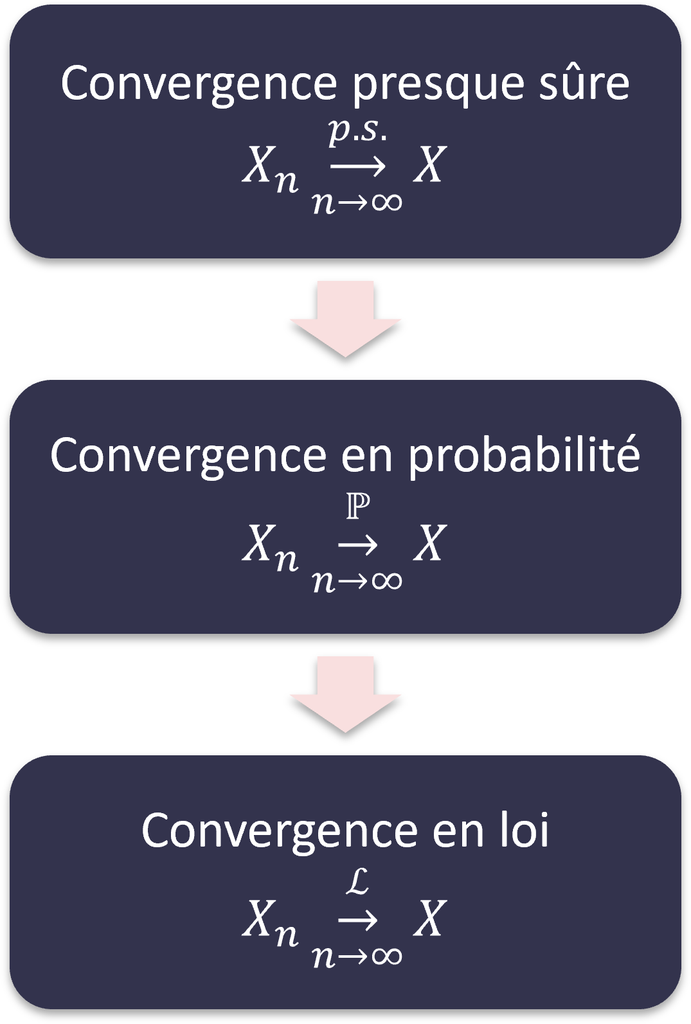

# Loi faible des grands nombres

Soit $X_1,...,X_n$ $n$ v.a.r. i.i.d.. La **moyenne de l’échantillon** (en. *sample mean*), notée $\bar{X_n}$, est une valeur définie par :
$$\bar{X_n} = \frac{1}{n}\sum_{i=1}^nX_i = \frac{X_1 + X_2 + ... + X_n}{n}$$

L’idée principale de la loi des grands nombres est que la moyenne du grand nombre de v.a.r. i.i.d. converge vers l’espérance. Ainsi, si on répète une expérimentation de manière indépendante un grand nombre de fois et on prend une moyenne des résultats obtenus, cette moyenne va être proche de l’espérance théorique.

**Loi faible des grands nombres** (en. *Weak law of large numbers* ou *WLLN*)

Soit $X_1,...,X_n$ $n$ v.a.r. i.i.d. de l’espérance $\mathbb{E}X_i = m < \infty, \forall i=1,...,n$ et la variance $Var(X_i) = \sigma^2 < \infty, \forall i=1,...,n$ finies. Soit $\bar{X_n} = \frac{1}{n}\sum_{i=1}^nX_i$.

Alors, $\bar{X_n}$ converge en probabilité vers $m$, $\bar{X_n}\xrightarrow[n\to +\infty]{\mathbb{P}}m$, i.e. :

$$\forall \epsilon>0, \ \lim\limits_{n\to + \infty}\mathbb{P}(|\bar{X_n} - m| \geq \epsilon) = 0$$

Pour le démontrer, on peut se servir de l’inégalité de Tchebychev :

$$\mathbb{P}(|\bar{X_n} - m| \geq \epsilon) \leq \frac{Var(\bar{X_n})}{\epsilon^2}$$

Notons que :

$$Var(\bar{X_n}) = Var\left(\frac{X_1 + ... + X_n}{n}\right) = \frac{1}{n^2}\times nVar(X) = \frac{1}{n^2}\times n\sigma^2 = \frac{\sigma^2}{n}$$

Alors :
$$\frac{Var(\bar{X_n})}{\epsilon^2} = \frac{\sigma^2}{n\epsilon^2} \xrightarrow[n\to +\infty]{} 0$$

# Loi forte des grands nombres

**Loi forte des grands nombres** (en. *Strong law of large numbers* ou *LLN*)

Soient $X_1,...,X_n$ $n$ v.a.r. i.i.d. de l’espérance $m$ finie. Soit $\bar{X_n} = \frac{1}{n}\sum_{i=1}^nX_i$.

Alors, $\bar{X_n}$ converge presque sûrement vers $m$, i.e. :

$$\bar{X_n}\xrightarrow[n\to +\infty]{p.s.}m$$

Autrement dit, $\exists \Omega_0\subset\Omega$ avec $\mathbb{P}(\overline{\Omega_0}) = \mathbb{P}(\Omega_0^C) = 0$ tel que $\forall \omega\in\Omega_0$ :

$$\lim\limits_{n\to +\infty}\bar{X_n}(\omega) = m$$

# Théorème de la limite centrale

L’idée principale du Théorème de la limite centrale est que sous certaines conditions, la somme du grand nombre de v.a.r. peut être approximée par la distribution normale.

**Théorème de la limite centrale** ou **TLC** (en. *Central Limit Theorem* ou *CLT*)

Soient $X_1, ..., X_n$ $n$ v.a.r. i.i.d. de moyenne $\mathbb{E}X_i = m < \infty, \ \forall i=1,...,n$ et de variance $Var(X_i) = \sigma^2 < \infty, \ \forall i=1,...,n$. Soit $S = \sum_{i=1}^nX_i = n\bar{X_n}$.

Alors :

$$\frac{S_n - nm}{\sigma\sqrt{n}} \xrightarrow[n\to + \infty]{\mathcal{L}} Y \sim \mathcal{N}(0,1)$$

Autrement dit,
$$\lim\limits_{n\to \infty} \mathbb{P}(S_n \leq x) = \Phi(x), \ \forall x\in \mathbb{R}$$
où $\Phi(x)$ est la fonction de répartition de la loi normale centrée réduite $\mathcal{N}(0,1)$.

Une formule équivalente qui est très utilisée est :
$$\frac{\bar{X} - m}{\sigma/\sqrt{n}} \xrightarrow[n\to + \infty]{\mathcal{L}} Y \sim \mathcal{N}(0,1)$$
où $\bar{X} = \frac{1}{n}\sum_{i=1}^nX_i$ est la moyenne de $X_1,...,X_n$.

**Remarque :** on applique la normalisation (standartisation) afin d’assurer l’espérance et la variance finies, car sinon $\mathbb{E}S_n = n\mathbb{E}X_i \xrightarrow[n\to\infty]{}\infty$ et $Var(S_n) = n\sigma^2 \xrightarrow[n\to\infty]{}\infty$. La variable aléatoire normalisée $Z_n = \frac{S_n - nm}{\sigma\sqrt{n}}$ a l’espérance et la variance finies, $\mathbb{E}Z_n = 0$, $Var(Z_n) = 1$. Notons que pour tout $n$ fixe, la fonction de densité de $Z_n$ est obtenue en changeant l’échelle et en deplaçant la fonction de densité de $S_n$. La forme de deux courbes est donc similaire.

> Quelle $n$ est considérée comme étant suffisamment grand afin d’appliquer le TLC ?

Dans le cas général, on considère qu’à partir de $n=30$, on peut utiliser l’approximation par la loi normale en se servant du TLC.

**Application du Théorème de la limite centrale**

1. Définir la variable aléatoire d’intérêt $Y$ comme la somme de $n$ v.a.r. i.i.d. $X_i, i=1,...,n$ :
   $$Y = X_1 + X_2 + ... + X_n$$
2. Trouver $\mathbb{E}Y$ et $Var(Y)$ comme :
   $$\mathbb{E}Y = n\mathbb{E}X_i = nm$$
   $$Var(Y) = nVar(X_i) = n\sigma^2$$
3. Selon $TLC$ : $\frac{Y - \mathbb{E}Y}{\sqrt{Var(Y)}} = \frac{Y - nm}{\sqrt{n}\sigma} \sim \mathcal{N}(0,1)$. Alors, on peut trouver $\mathbb{P}(y_1 \leq Y\leq y_2)$ comme suit :

$$\mathbb{P}(y_1 \leq Y\leq y_2) = \mathbb{P}\left(\frac{y_1 - nm}{\sqrt{n}\sigma} \leq \frac{Y - nm}{\sqrt{n}\sigma}\leq \frac{y_2 - nm}{\sqrt{n}\sigma}\right) \approx \Phi \left(\frac{y_2 - nm}{\sqrt{n}\sigma}\right) - \Phi \left(\frac{y_1 - nm}{\sqrt{n}\sigma}\right)$$

## Quelques distributions intéressantes

Soient $X_1,...,X_n$ $n$ v.a.r. i.i.d. de loi de Bernoulli $X_i \sim \mathcal{B}(p), \ i = 1,...,n$. Soit $S_n = \sum_{i=1}^n X_i$.

Alors :

1. $S_n$ suit la loi binomiale $S_n \sim \mathcal{B}(n,p)$
2. $S_n \xrightarrow[n\to + \infty]{\mathcal{L}} Y\sim \mathcal{N}(np, np(1-p))$

On peut voir l’idée du TLC avec la simulation.

Soient $X_1,...,X_n$ $n$ v.a.r. i.i.d. de loi de Bernoulli $X_i \sim \mathcal{B}(p), \ i = 1,...,n$. Posons pour l’exemple $p = 0.3$.

De point de vue théorique, pour la loi de Berboulli $X \sim \mathcal{B}(p=0.3)$ :

- $m = p = 0.3$
- $Var(X) = p(1-p) = 0.3 \times (1 - 0.3) = 0.3 \times 0.7 = 0.21$

La fonction de masse de $X$ est donnée par :
$$\left\{\begin{array}{l}\mathbb{P}(X = 1) = p = 0.3 \\ \mathbb{P}(X = 0) = 1 - p = 0.7 \end{array}\right.$$

Graphiquement, on a :

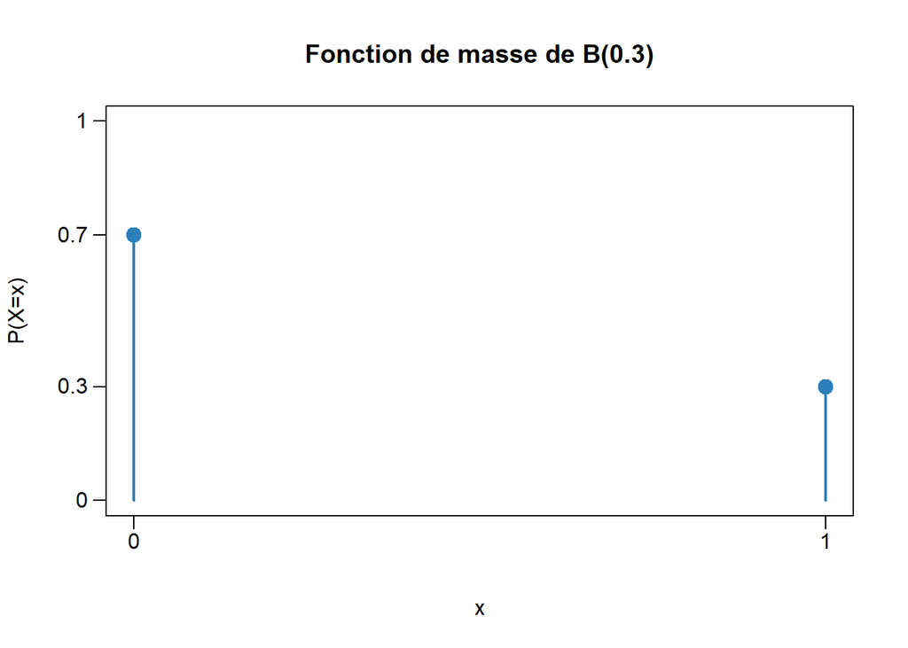

```r
p <- 0.3 # paramètre p de la distribution de Bernoulli
x <- c(0,1) # valeurs possibles de X

# graphique
plot(x, dbinom(x, size = 1, prob = p), main = "Fonction de masse de B(0.3)",
     xlab="x", ylab="P(X=x)",
     col = brewer.pal(5, "YlGnBu")[4], pch = 19, cex = 1.5,
     ylim = c(0, 1), xaxt="n", yaxt="n")
xtick <- c(0, 1)
axis(side=1, at=xtick, labels = FALSE)
text(x=xtick,  par("usr")[3], offset = 0.7,
     labels = xtick, pos = 1, xpd = TRUE)
ytick <- c(0, 0.3, 0.7, 1)
axis(side=2, at=ytick, labels = FALSE)
text(par("usr")[1], ytick, offset = 0.7,
     labels = ytick, pos = 2, xpd = TRUE)
lines(x=c(0,0), y=c(0, dbinom(0, size = 1, prob = p)),
      col = brewer.pal(5, "YlGnBu")[4], lwd = 2)
lines(x=c(1,1), y=c(0, dbinom(1, size = 1, prob = p)),
      col = brewer.pal(5, "YlGnBu")[4], lwd = 2)
```

Passons maintenant à la simulation.

L’idée de la simulation est la suivante :

1. Prendre un certain nombre d’échantillons / observations $k$ de $n$ tirages (e.g. $n = \left\{1, 5, 10, 30, 50, 100\right\}$) et enregistrer les $X_i,\ i=1,...,n$
2. Calculer $S_n = \sum_{i=1}^nX_i$. Nous savons que $S_n\sim \mathcal{B}(n,p)$ (loi binomiale)
3. Normaliser $S_n$ en obtenant $Z_n = \frac{S_n - np}{\sqrt{np(1-p)}}$
4. Visualiser la fonction de masse de $S_n$ et $Z_n$

Commençons avec un seul tirage $n=1$.

*Remarque* : dans le `R` il est possible de générer des v.a. suivant la loi binomial avec la fonction `rbinom()`. Pour rappel, un loi de Bernoulli correspond à un tirage de la loi Binomial $\mathcal{B}(n=1,p)$.

```r
p <- 0.3 # probabilité de succès
k <- 10 # nombre d'observations
n <- 1 # nombre de tirages (Bernoulli correspond à un tirage de la loi binomial)
# espérance
m <- n * p
# variance
var <- n * p * (1 - p)

# fixer la graine (seed) du générateur aléatoire pour la reproducibilité
set.seed(23)

# générer n=k observations de size=n tirages de la loi binomial
x <- rbinom(n=k, size=n, prob=p); x
```

```
##  [1] 0 0 0 1 1 0 1 1 1 1
```

```r
# normaliser Sn
zn <- (x - n*p)/(sqrt(n*p*(1 - p))) ; zn
```

```
##  [1] -0.6546537 -0.6546537 -0.6546537  1.5275252  1.5275252 -0.6546537  1.5275252  1.5275252
##  [9]  1.5275252  1.5275252
```

On remarque que parmis les $k=$ 10 observations, i.e. valeurs obtenues (d’une manière aléatoire) `x`, on obtient le nombre d’occurrences suivant :

```r
# data frame contenant les effectifs de valeurs
freq <- as.data.frame(table(x)); freq
```

```
##   x Freq
## 1 0    4
## 2 1    6
```

```r
# calcul de la fréquence de l'occurrence de chaque valeur
freq$RelFreq = freq$Freq / sum(freq$Freq)
```

Ce résultat pourrait être visualisé de la façon suivante :

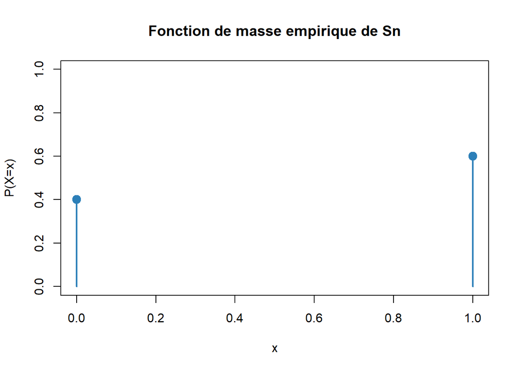

```r
# graphique
plot(as.numeric((as.vector(freq$x))), c(freq$RelFreq),
     main = "Fonction de masse empirique de Sn",
     xlab="x", ylab="P(X=x)",
     col = brewer.pal(5, "YlGnBu")[4], pch = 19, cex = 1.5,
     ylim = c(0, 1))
lines(x=c(0,0), y=c(0, freq$RelFreq[1]),
      col = brewer.pal(5, "YlGnBu")[4], lwd = 2)
lines(x=c(1,1), y=c(0, freq$RelFreq[2]),
      col = brewer.pal(5, "YlGnBu")[4], lwd = 2)
```

Nous remarquons que cet état ne correspond pas forcément à la fonction de densité théorique de $X\sim\mathcal{B}(0.3)$.

Varions $n$ et augmentons $k = 200$. Notons que pour $n$ v.a.r., les valeurs possibles de $S_n$ vont être $\left\{0,1,...,n\right\}$, où $S_n = n$ si toutes les $X_i = 1, \forall i=1,...,n$.

```r
# nombre d'observations (échantillons)
k <- 200
# options pour n
nn <- c(1, 5, 10, 30, 50, 100)
# param p de la distribution de Bernoulli
p <- 0.3
```

Pour la visualisation des simulations on peut se servir de la fonction suivante :

```r
getDistPlot <- function(n=50, k=100, p=0.3, standard = FALSE){
  # génération de k observqtions de v.a. de la loi binomiale
  # avec prob=p, nombre de tirages size=n
  rv <- rbinom(n=k, size=n, prob=p)
  m <- n * p # espérance
  sigma2 <- n * p * (1 - p) # variance
  # standartisé ou pas
  if (standard){
    # standartisation de rv
    rv <- (rv - m) / sqrt(sigma2)
    # loi normale centrée réduite
    xx <- seq(-sqrt(n*p/(1-p))-1, sqrt(n*(1-p)/p) + 1, 0.1)
    y <- dnorm(xx, mean = 0, sd = 1)

    pdfLegend <- "pdf N(0, 1)"

  } else {
    # loi normale avec les params (np, sqrt(np(1-p)))
    xx <- seq(0, n, 0.1)
    y <- dnorm(xx, mean = m, sd = sqrt(sigma2))

    pdfLegend <- "pdf N(np, np(1-p))"
  }

  # data frame contenant les effectifs de valeurs
  freq <- as.data.frame(table(rv))
  # calcul de la fréquence de l'occurrence de chaque valeur
  freq$RelFreq = freq$Freq / sum(freq$Freq)
  # graphique
  if (standard){
    # histogramme
    p.plot <- hist(rv, freq=FALSE,
                   main=paste("Histogramme de Sn standartisé, n = ",
                              as.character(n), sep = ""),
                   xlab="x", ylab="P(X=x)",
                   ylim = c(0, max(c(freq$RelFreq, y)) + 0.1),
                   col = brewer.pal(5, "YlGnBu")[4],
                   breaks = min(round(sqrt(n*p/(1-p))), 5)
                   )
  } else {
    # scatterplot
    p.plot <- plot(as.numeric((as.vector(freq$rv))), c(freq$RelFreq),
       main = paste("Fonction de masse empirique de Sn, n = ",
                    as.character(n), sep = ""),
       xlab="x", ylab="P(X=x)",
       col = brewer.pal(5, "YlGnBu")[4], pch = 19, cex = 1.5,
       ylim = c(0, max(c(freq$RelFreq, y)) + 0.1))
  }
  # ajout de la fonction de densité de la loi normale N(np, np(1-p)
  lines(xx, y, col =  brewer.pal(5, "RdPu")[4])
  # légende
  legend("topright", legend=c("Sn", pdfLegend),
       col=c(brewer.pal(5, "YlGnBu")[4], brewer.pal(5, "RdPu")[4]),
       lty=1, cex=0.8, pch=c(19,20))

  return(p.plot)
}
```

Lançons les simulations :

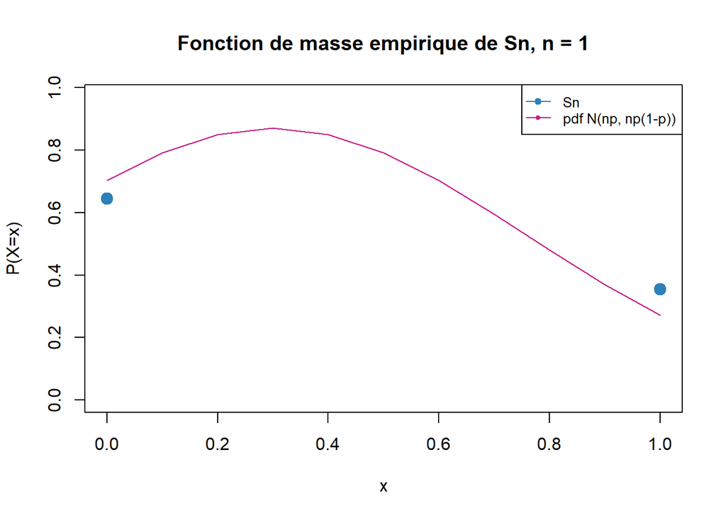

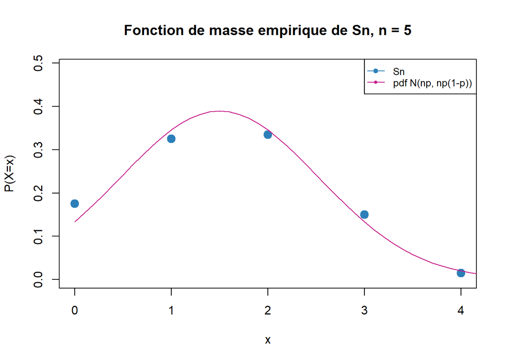

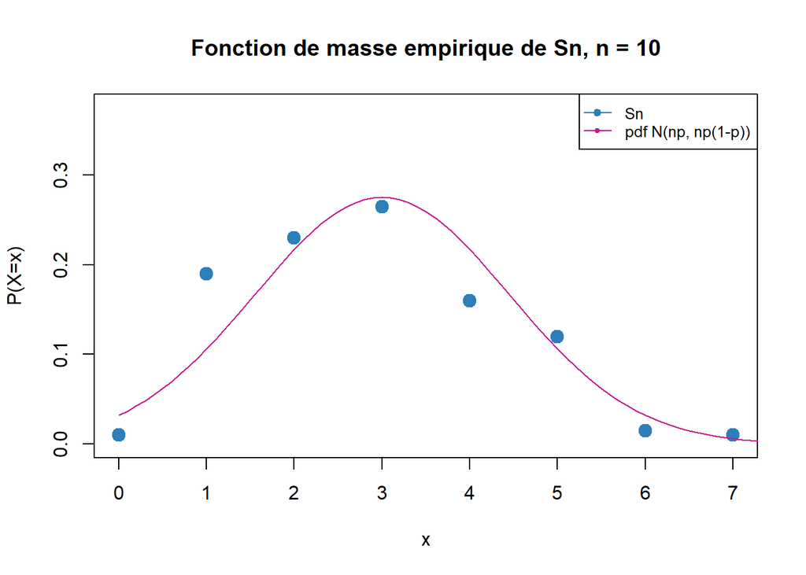

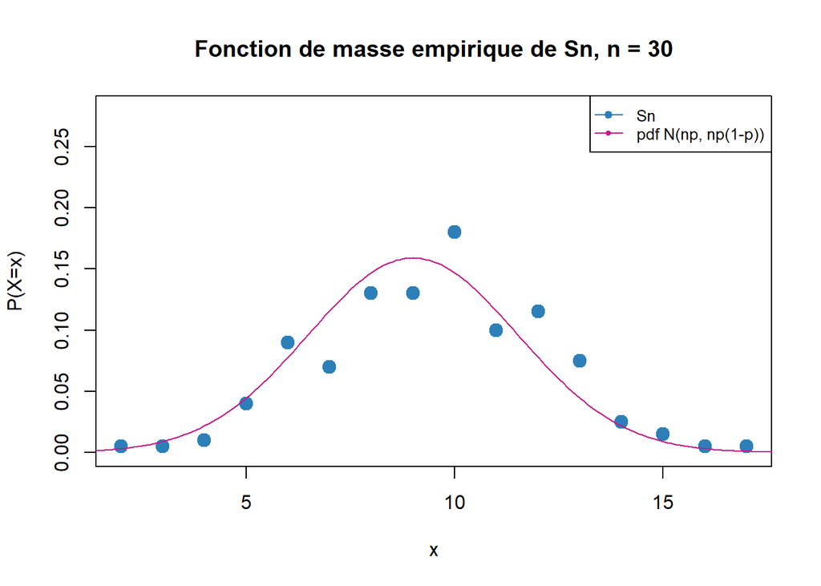

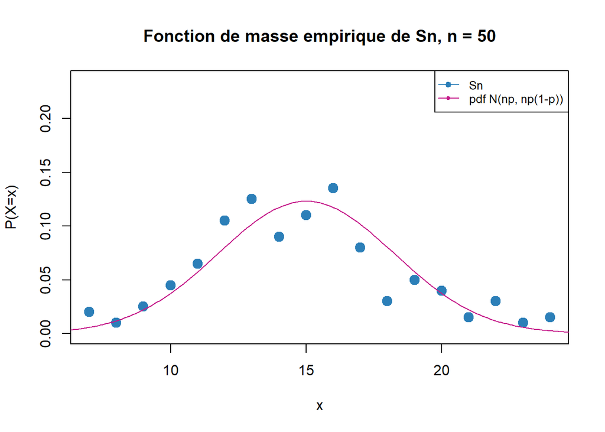

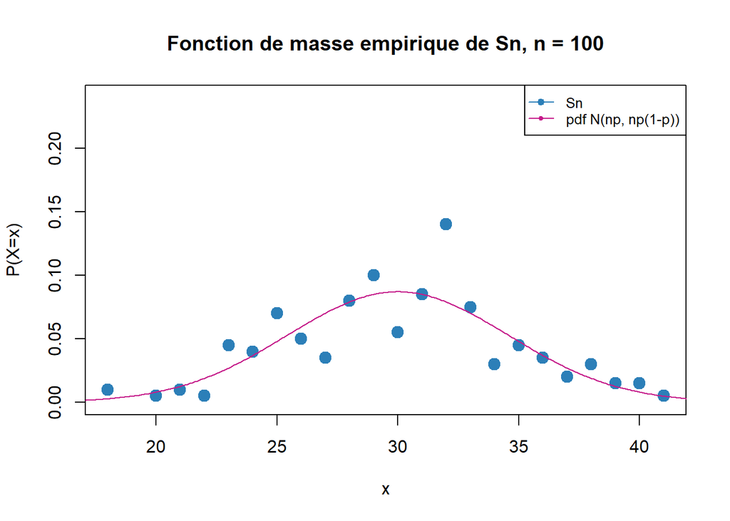

```r
for (n in nn){
  plt <- getDistPlot(n=n, k=k, p=p, standard=FALSE)
}
```

La version standartisée de $S_n$ avec une histogramme :

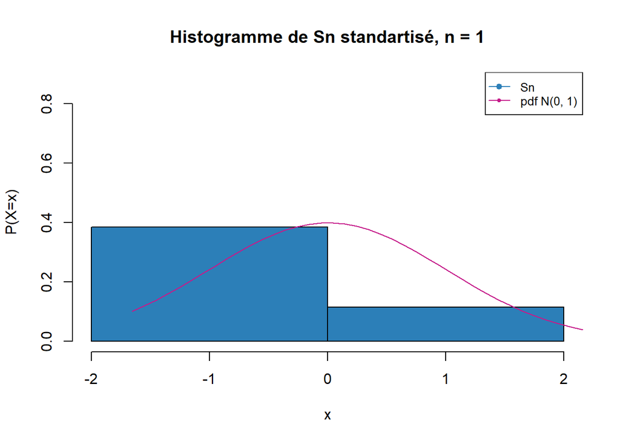

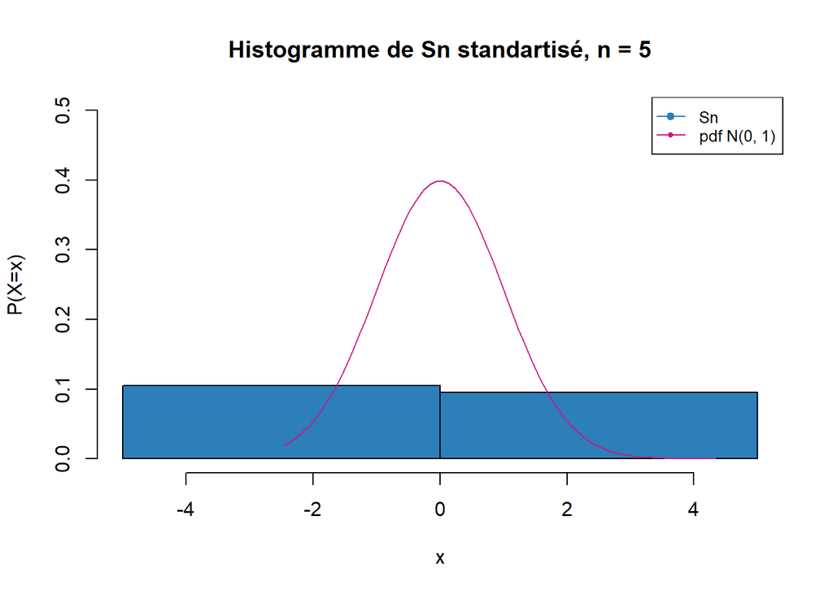

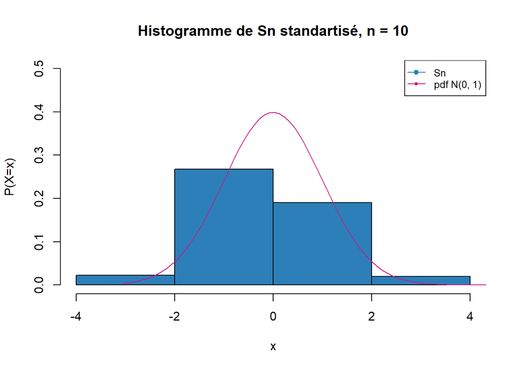

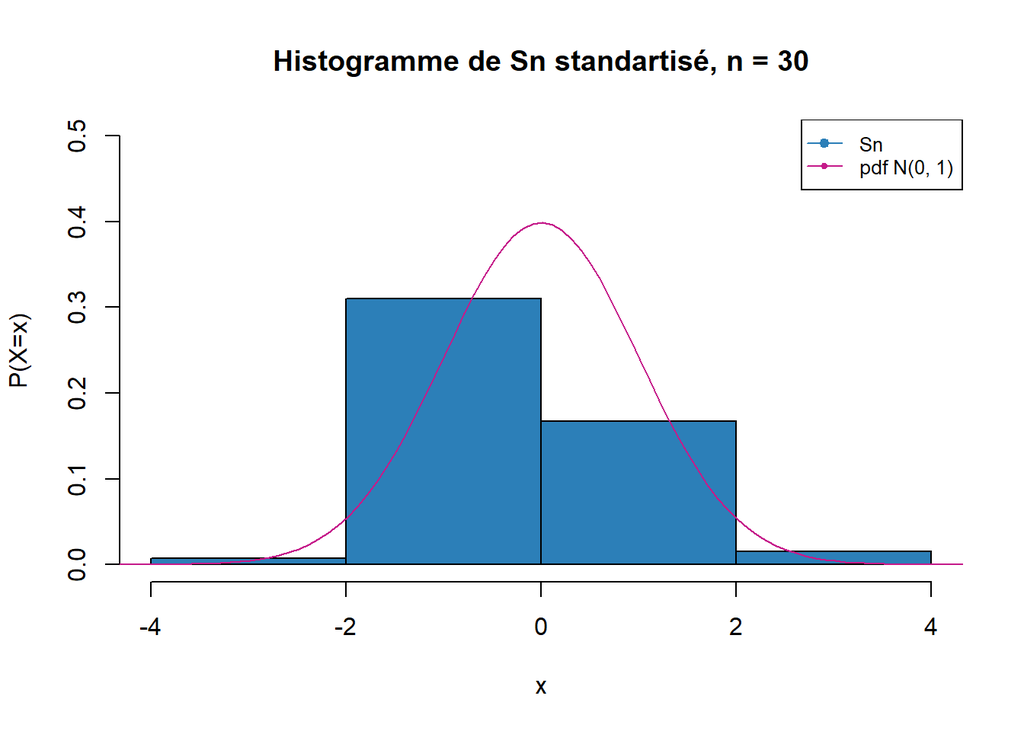

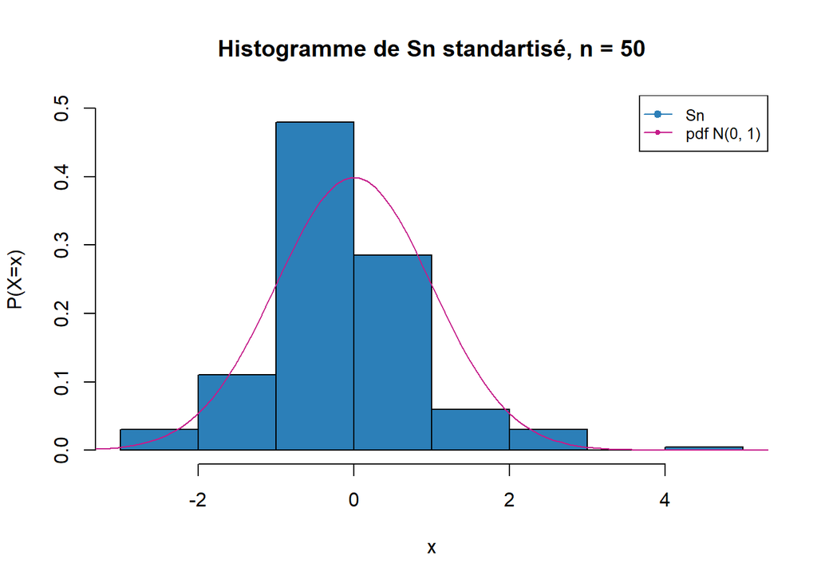

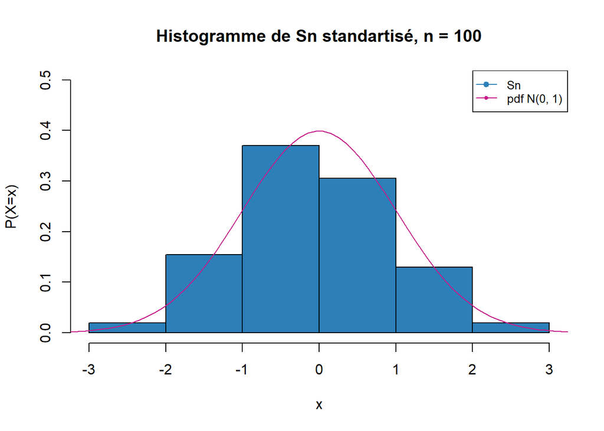

```r
for (n in nn){
  plt <- getDistPlot(n=n, k=k, p=p, standard=TRUE)
}
```

On remarque bien que avec la croissance de $n$, on s’approche de la loi normale, même si la loi initiale des $X_i,\ i=1,...,n$ est discrète.

Un autre exemple consiste de la loi de Poisson.

Soient $X_1,...,X_n$ $n$ v.a.r. i.i.d. de loi de Poisson $X_i \sim \mathcal{P}(\lambda)$. Soit $S_n = \sum_{i=1}^n X_i$.

Alors :

1. $S_n$ suit la loi de Poisson $S_n \sim \mathcal{P}(n\lambda)$
2. $S_n \xrightarrow[n\to + \infty]{\mathcal{L}} Y\sim \mathcal{N}(n\lambda, n\lambda)$

# Liens utiles

1. Jeremy Orloff, and Jonathan Bloom. *18.05 Introduction to Probability and Statistics*. Spring 2014. Massachusetts Institute of Technology: MIT OpenCourseWare, https://ocw.mit.edu. License: Creative Commons BY-NC-SA.

# References

Pishro-Nik, Hossein. 2014. *Introduction to Probability, Statistics, and Random Processes*. Blue Bell, PA: Kappa Research, LLC. https://www.probabilitycourse.com/.

Stéphane Balac, and Olivier Mazet. n.d. “Introduction aux Probabilités.” Centre de Mathématiques. Institut National des Sciences Appliquées de Lyon. Accessed May 13, 2021. https://perso.univ-rennes1.fr/stephane.balac/publis/polypbs.pdf.